# Exercise Deivces - Prediction of Quality

Stefan Kosztolanyi

March 11, 2017

## Overview

In this analysis, we look at Weight Lifting Exercise Dataset that was carefully corrected for 6 participants in experimental conditions. We won’t be concerned about the lenght of exercise or count of exercises. Rather, we are concerned about whether participant exercised correctly (class A) or he did some common mistake during the exercise (clas B - E).

## Exploratory Analysis

```r
missing_vals_cols <- colnames(train)[colSums(is.na(train)) > 0]
missing_vals_cols
```

```
##  [1] "max_roll_belt"            "max_picth_belt"
##  [3] "min_roll_belt"            "min_pitch_belt"
##  [5] "amplitude_roll_belt"      "amplitude_pitch_belt"
##  [7] "var_total_accel_belt"     "avg_roll_belt"
##  [9] "stddev_roll_belt"         "var_roll_belt"
## [11] "avg_pitch_belt"           "stddev_pitch_belt"
## [13] "var_pitch_belt"           "avg_yaw_belt"
## [15] "stddev_yaw_belt"          "var_yaw_belt"
## [17] "var_accel_arm"            "avg_roll_arm"
## [19] "stddev_roll_arm"          "var_roll_arm"
## [21] "avg_pitch_arm"            "stddev_pitch_arm"
## [23] "var_pitch_arm"            "avg_yaw_arm"
## [25] "stddev_yaw_arm"           "var_yaw_arm"
## [27] "max_roll_arm"             "max_picth_arm"
## [29] "max_yaw_arm"              "min_roll_arm"
```

[output cut: 19 more lines]

As we see, there are 67 columns that contain NA values and all of the columns contain 19216 missing values. That is quite a lot given we have 19622 observations. We will therefore ignore these columns and build a model only from the columns without missing values.

```r
train_without_NA <- train[,! names(train) %in% missing_vals_cols]
```

Let’s look at the outcome variable and see how many observations are there for every class in percentage values.

```r
table(train_without_NA$classe)/sum(table(train_without_NA$classe))
```

```
##
##         A         B         C         D         E
## 0.2843747 0.1935073 0.1743961 0.1638977 0.1838243
```

The class A which means correct training is the most observed, while incorrect values have all very similar observation count. This is important fact for our model building.

## Building a Predictive Model with Cross Validation

Before we build a model, we want to split the tran_without_NA dataset into training and validation dataset for better estimates of model accuracy. We will use caret package for splitting on the outcome.

```r
set.seed(315)
train_index <- createDataPartition(train_without_NA$classe, p = 0.7, list = FALSE)
training <- train_without_NA[train_index,]
validation <- train_without_NA[-train_index,]
```

When deciding what modeling algorithm to use, we usually decide between simplicity and straightforward interpretability compared to compleity and higher accuracy.

The first kind of simple and interpretable models would be Logistic Regression model (glm, family = “multinomial”) or decision tree model (rpart).

The second kind of complex and not easily interpretable models would be for example Random Forests (method = “rf”) or Gradient Boosting (method = “gbm”).

It’s usually better to start with simpler model and decide if to build more complex model or use the simple one based on the prediction results.

**1. Logistic Regression Model**

```r
# LogReg_Mod <- train(classe ~ ., data = training, method = "glm", family = "binomial")
```

Aha! We won’t be able to use glm logistic regression, because it only accepts binomial family (2 different outcomes), while we have 5 different outcomes. Let’s look at decision tree.

**2. Desicion Tree Model**

```r
library(rpart)
DecTree_Mod1 <- train(classe ~ total_accel_belt
                     + total_accel_arm
                     + total_accel_dumbbell
                     + total_accel_forearm
                     ,data = training, method = "rpart")
```

```r
library(rpart.plot)
DecTree_Predict <- predict(DecTree_Mod1, newdata = training)
confusionMatrix(DecTree_Predict, training$classe)
```

```
## Confusion Matrix and Statistics
##
##           Reference
## Prediction    A    B    C    D    E
##          A 2383  658  785 1164  539
##          B 1453 1988 1611 1087 1285
##          C    0    0    0    0    0
##          D    0    0    0    0    0
##          E   70   12    0    1  701
##
## Overall Statistics
##
##                Accuracy : 0.3692
##                  95% CI : (0.3611, 0.3774)
##     No Information Rate : 0.2843
##     P-Value [Acc > NIR] : < 2.2e-16
##
##                   Kappa : 0.1813
##  Mcnemar's Test P-Value : NA
##
## Statistics by Class:
##
##                      Class: A Class: B Class: C Class: D Class: E
## Sensitivity            0.6101   0.7479   0.0000   0.0000  0.27762
## Specificity            0.6800   0.5093   1.0000   1.0000  0.99260
## Pos Pred Value         0.4310   0.2678      NaN      NaN  0.89413
## Neg Pred Value         0.8144   0.8939   0.8256   0.8361  0.85918
## Prevalence             0.2843   0.1935   0.1744   0.1639  0.18381
## Detection Rate         0.1735   0.1447   0.0000   0.0000  0.05103
## Detection Prevalence   0.4025   0.5404   0.0000   0.0000  0.05707
## Balanced Accuracy      0.6450   0.6286   0.5000   0.5000  0.63511
```

```r
DecTree_Mod2 <- train(classe ~ total_accel_belt + roll_belt + pitch_belt + yaw_belt
                     + total_accel_arm + roll_arm + pitch_arm + yaw_arm
                     + total_accel_dumbbell + roll_dumbbell + pitch_dumbbell + yaw_dumbbell
                     + total_accel_forearm + roll_forearm + pitch_forearm + yaw_forearm
                     ,data = training, method = "rpart")

DecTree_Predict2 <- predict(DecTree_Mod2, newdata = training)
confusionMatrix(DecTree_Predict2, training$classe)
```

```
## Confusion Matrix and Statistics
##
##           Reference
## Prediction    A    B    C    D    E
##          A 3619 1290 1094 1378  497
##          B   11  470   56   15   12
##          C  267  898 1246  859  858
##          D    0    0    0    0    0
##          E    9    0    0    0 1158
##
## Overall Statistics
##
##                Accuracy : 0.4727
##                  95% CI : (0.4643, 0.4811)
##     No Information Rate : 0.2843
##     P-Value [Acc > NIR] : < 2.2e-16
##
##                   Kappa : 0.307
##  Mcnemar's Test P-Value : NA
##
## Statistics by Class:
##
##                      Class: A Class: B Class: C Class: D Class: E
## Sensitivity            0.9265  0.17682   0.5200   0.0000  0.45861
## Specificity            0.5668  0.99152   0.7459   1.0000  0.99920
## Pos Pred Value         0.4594  0.83333   0.3018      NaN  0.99229
## Neg Pred Value         0.9510  0.83390   0.8803   0.8361  0.89125
## Prevalence             0.2843  0.19349   0.1744   0.1639  0.18381
## Detection Rate         0.2634  0.03421   0.0907   0.0000  0.08430
## Detection Prevalence   0.5735  0.04106   0.3005   0.0000  0.08495
## Balanced Accuracy      0.7467  0.58417   0.6330   0.5000  0.72891
```

I think big problem with modeling is choosing the correct variables. What should be included and what shouldn’t? Let’s include only those variables that don’t contain NA and missing values(most factor variables) and use only those - complete numeric variables.

```r
training_numeric <- training[,sapply(training, is.numeric)]
training_numeric <- cbind(data.frame(classe = training$classe), training_numeric)
```

```r
DecTree_Mod3 <- train(classe ~ . -X -raw_timestamp_part_1 -raw_timestamp_part_2 -num_window
                     ,data = training_numeric
                     , method = "rpart"
                     ,trControl = trainControl(method = "cv", number = 5))

DecTree_Predict3 <- predict(DecTree_Mod3, newdata = training_numeric)
confusionMatrix(DecTree_Predict3, training$classe)
```

```
## Confusion Matrix and Statistics
##
##           Reference
## Prediction    A    B    C    D    E
##          A 3569 1069 1109 1009  369
##          B   59  919   85  394  330
##          C  269  670 1202  849  668
##          D    0    0    0    0    0
##          E    9    0    0    0 1158
##
## Overall Statistics
##
##                Accuracy : 0.4985
##                  95% CI : (0.4901, 0.5069)
##     No Information Rate : 0.2843
##     P-Value [Acc > NIR] : < 2.2e-16
##
##                   Kappa : 0.3447
##  Mcnemar's Test P-Value : NA
##
## Statistics by Class:
##
##                      Class: A Class: B Class: C Class: D Class: E
## Sensitivity            0.9137   0.3457   0.5017   0.0000  0.45861
## Specificity            0.6383   0.9217   0.7834   1.0000  0.99920
## Pos Pred Value         0.5009   0.5143   0.3286      NaN  0.99229
## Neg Pred Value         0.9490   0.8545   0.8815   0.8361  0.89125
## Prevalence             0.2843   0.1935   0.1744   0.1639  0.18381
## Detection Rate         0.2598   0.0669   0.0875   0.0000  0.08430
## Detection Prevalence   0.5187   0.1301   0.2663   0.0000  0.08495
## Balanced Accuracy      0.7760   0.6337   0.6426   0.5000  0.72891
```

```r
DecTree_val3 <- predict(DecTree_Mod3, newdata = validation)
confusionMatrix(DecTree_val3, validation$classe)
```

```
## Confusion Matrix and Statistics
##
##           Reference
## Prediction    A    B    C    D    E
##          A 1503  492  477  427  155
##          B   22  367   23  174  156
##          C  144  280  526  363  298
##          D    0    0    0    0    0
##          E    5    0    0    0  473
##
## Overall Statistics
##
##                Accuracy : 0.4875
##                  95% CI : (0.4747, 0.5004)
##     No Information Rate : 0.2845
##     P-Value [Acc > NIR] : < 2.2e-16
##
##                   Kappa : 0.3304
##  Mcnemar's Test P-Value : NA
##
## Statistics by Class:
##
##                      Class: A Class: B Class: C Class: D Class: E
## Sensitivity            0.8978  0.32221  0.51267   0.0000  0.43715
## Specificity            0.6317  0.92099  0.77670   1.0000  0.99896
## Pos Pred Value         0.4921  0.49461  0.32651      NaN  0.98954
## Neg Pred Value         0.9396  0.84989  0.88301   0.8362  0.88737
## Prevalence             0.2845  0.19354  0.17434   0.1638  0.18386
## Detection Rate         0.2554  0.06236  0.08938   0.0000  0.08037
## Detection Prevalence   0.5189  0.12608  0.27375   0.0000  0.08122
## Balanced Accuracy      0.7648  0.62160  0.64469   0.5000  0.71806
```

**3. Random Forest Model**

```r
library(randomForest)
RF_Mod1 <- randomForest(x = training_numeric[,!colnames(training_numeric) %in% c("X", "raw_timestamp_part_1", "raw_timestamp_part_2", "num_window", "classe")]
                  , y = training_numeric$classe
                  ,  ntree = 50)

RF_Predict1 <- predict(RF_Mod1, newdata = training_numeric)
confusionMatrix(RF_Predict1, training$classe)
```

```
## Confusion Matrix and Statistics
##
##           Reference
## Prediction    A    B    C    D    E
##          A 3906    0    0    0    0
##          B    0 2658    0    0    0
##          C    0    0 2396    0    0
##          D    0    0    0 2252    0
##          E    0    0    0    0 2525
##
## Overall Statistics
##
##                Accuracy : 1
##                  95% CI : (0.9997, 1)
##     No Information Rate : 0.2843
##     P-Value [Acc > NIR] : < 2.2e-16
##
##                   Kappa : 1
##  Mcnemar's Test P-Value : NA
##
## Statistics by Class:
##
##                      Class: A Class: B Class: C Class: D Class: E
## Sensitivity            1.0000   1.0000   1.0000   1.0000   1.0000
## Specificity            1.0000   1.0000   1.0000   1.0000   1.0000
## Pos Pred Value         1.0000   1.0000   1.0000   1.0000   1.0000
## Neg Pred Value         1.0000   1.0000   1.0000   1.0000   1.0000
## Prevalence             0.2843   0.1935   0.1744   0.1639   0.1838
## Detection Rate         0.2843   0.1935   0.1744   0.1639   0.1838
## Detection Prevalence   0.2843   0.1935   0.1744   0.1639   0.1838
## Balanced Accuracy      1.0000   1.0000   1.0000   1.0000   1.0000
```

The prediction on training dataset is 100% accurate! I’m afraid, there is huge overfitting going on, so let’s apply the model to validation dataset that we set apart in the beginning.

```r
RF_Validation1 <- predict(RF_Mod1, newdata = validation)
confusionMatrix(RF_Validation1, validation$classe)
```

```
## Confusion Matrix and Statistics
##
##           Reference
## Prediction    A    B    C    D    E
##          A 1672    4    0    0    0
##          B    1 1134    3    0    0
##          C    0    1 1023   10    0
##          D    0    0    0  954    0
##          E    1    0    0    0 1082
##
## Overall Statistics
##
##                Accuracy : 0.9966
##                  95% CI : (0.9948, 0.9979)
##     No Information Rate : 0.2845
##     P-Value [Acc > NIR] : < 2.2e-16
##
##                   Kappa : 0.9957
##  Mcnemar's Test P-Value : NA
##
## Statistics by Class:
##
##                      Class: A Class: B Class: C Class: D Class: E
## Sensitivity            0.9988   0.9956   0.9971   0.9896   1.0000
## Specificity            0.9991   0.9992   0.9977   1.0000   0.9998
## Pos Pred Value         0.9976   0.9965   0.9894   1.0000   0.9991
## Neg Pred Value         0.9995   0.9989   0.9994   0.9980   1.0000
## Prevalence             0.2845   0.1935   0.1743   0.1638   0.1839
## Detection Rate         0.2841   0.1927   0.1738   0.1621   0.1839
## Detection Prevalence   0.2848   0.1934   0.1757   0.1621   0.1840
## Balanced Accuracy      0.9989   0.9974   0.9974   0.9948   0.9999
```

Finally, let’s look at importance of different variables (higher the value, the more important feature)

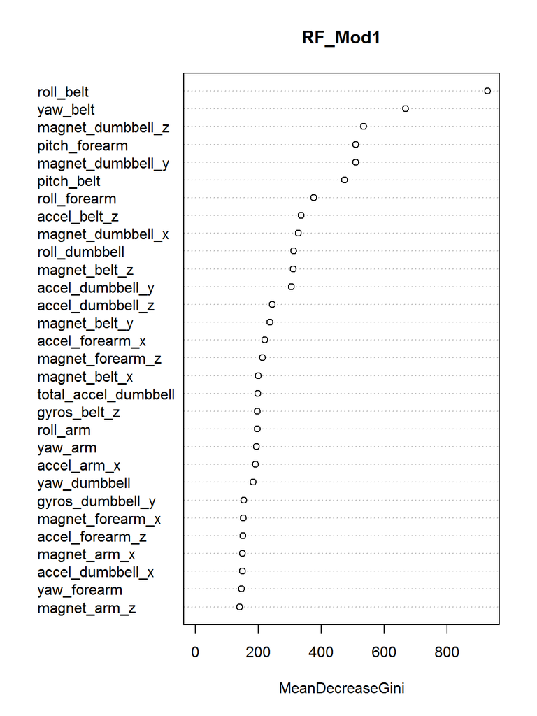

```r
varImpPlot(RF_Mod1, type = 2)
```

## Model Evaluation and Model Selection

We used only numeric features without missing values as predictors in our final models.

At first, we wanted to build an easily interpretable model with Logistic Regression, but it wasn’t possible, because we have 5 classes to predict and not only binomial 2.

Then we built a decision tree model with cross validation, but it had only accuracy of 49% on training set and 48% on validation set.

## Applying the Best Model on Test Dataset

There are a few missing values in test dataset for fields that are filled in training dataset. We could either remove all such fields from the model and build a model without them or just fill 0 value and hope that they are not so important.

```r
test_fill <- test
test_fill[is.na(test_fill)] <- 0
RF_Test1 <- predict(RF_Mod1, newdata = test_fill)
RF_Test1
```

```
##  1  2  3  4  5  6  7  8  9 10 11 12 13 14 15 16 17 18 19 20
##  B  A  B  A  A  E  D  B  A  A  B  C  B  A  E  E  A  B  B  B
## Levels: A B C D E
```

According to the quiz, we have also 100% accuracy here.